# BIO 392 - CNV.Freq

Eric Thiele

2023-09-27

# Tumor Information

Uncontrolled proliferation and spread of abnormal cells within the breast tissue is a characteristic of invasive breast cancer. In more advanced stages, these malignant cells may travell through the bloodstream or lymphatic system to distant regions of the body in addition to having the capacity to invade neighbouring tissues. Breast cancer most often occurs in women between 50 to 74, but can also occur in men.

# Invasive Breast Carcinoma

The NCIt code is C9245

# Access the CNV frequency data

- load library

```r
library(pgxRpi)
```

# Access data

```r
freq <- pgxLoader(type='frequency', output='pgxfreq', filters='NCIT:C9245')
```

- The metadata information is

```r
freq$meta
```

```
##         code                     label sample_count
## 1 NCIT:C9245 Invasive Breast Carcinoma         3796
## 2      total                                   3796
```

- The data looks like this

```r
freq$data$`NCIT:C9245`[c(1:3),]
```

```
##      filters reference_name   start     end gain_frequency loss_frequency no
## 1 NCIT:C9245              1       0  400000          2.397          1.159  1
## 2 NCIT:C9245              1  400000 1400000          4.083          7.877  2
## 3 NCIT:C9245              1 1400000 2400000          2.608          6.981  3
```

# Visualisation

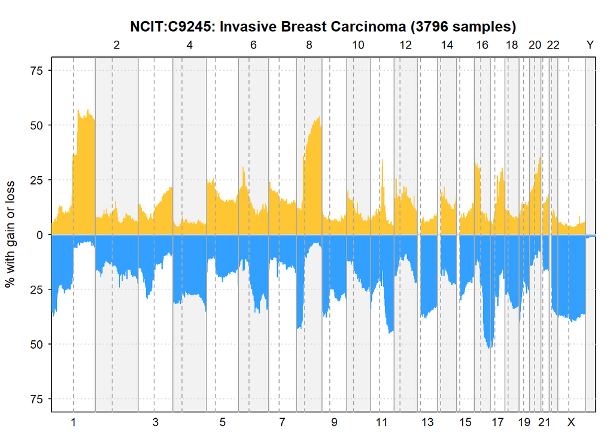

```r
pgxFreqplot(freq)
```

The given bars show the CN increase of a chromosome, whereas the blue ones indicate CN loss relative to the whole reference genome.

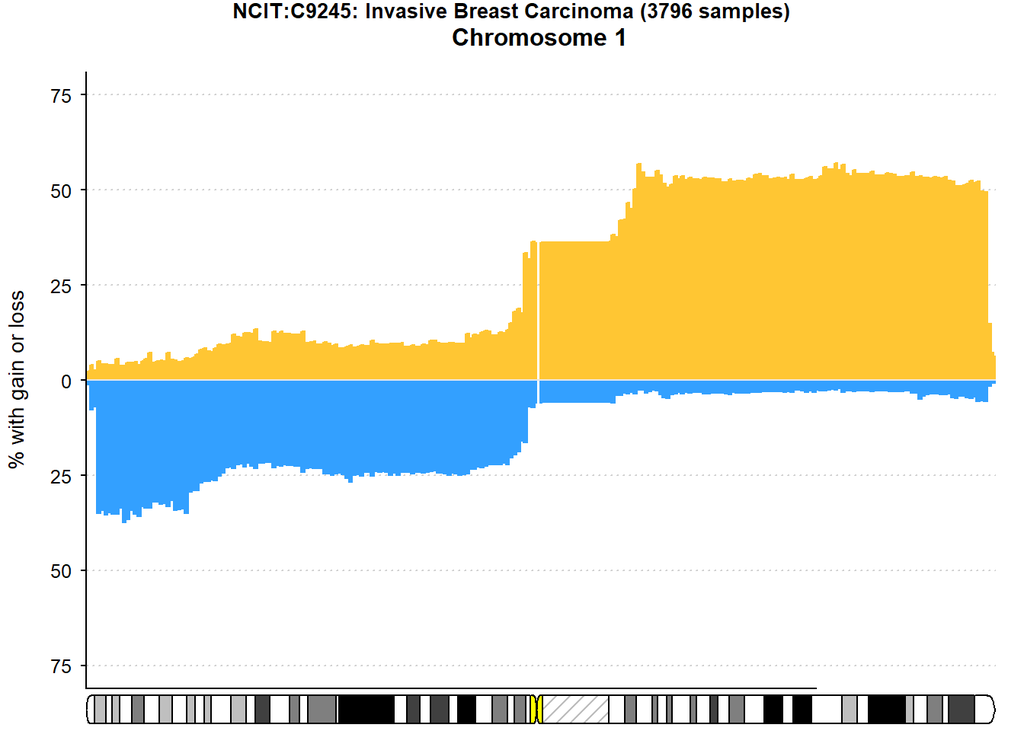

```r
pgxFreqplot(freq, chrom=1)
```

There is a clear gain of CN in the q-part of the chromosome 1. The gain of the CN’s in Chromosome 1 often correlates with breast carcinoma.

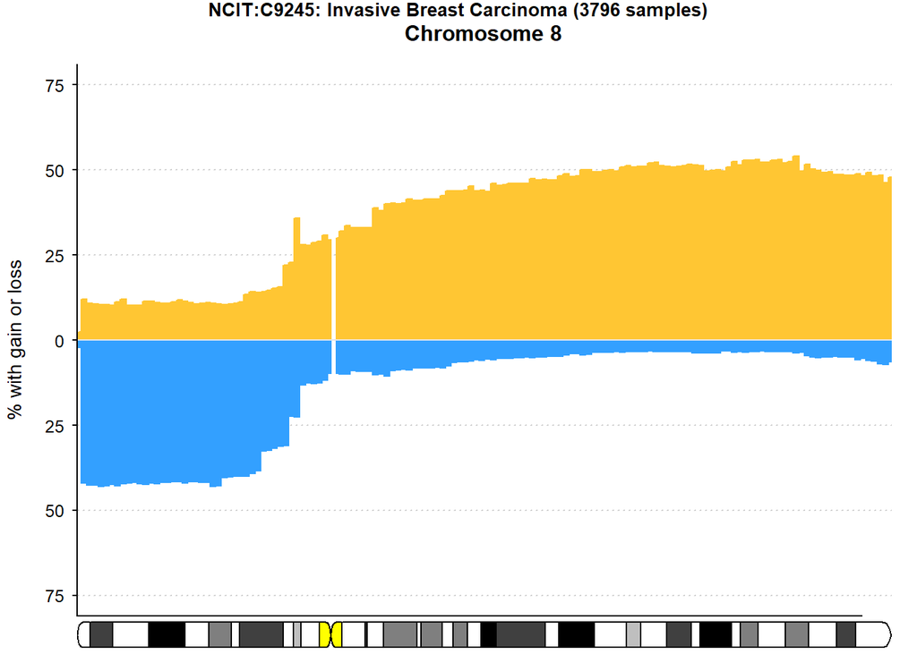

```r
pgxFreqplot(freq, chrom=8)
```

In the 8th chromosome, you can see on the one end deletions as well as a gain of CN’s on the longer q-arm.

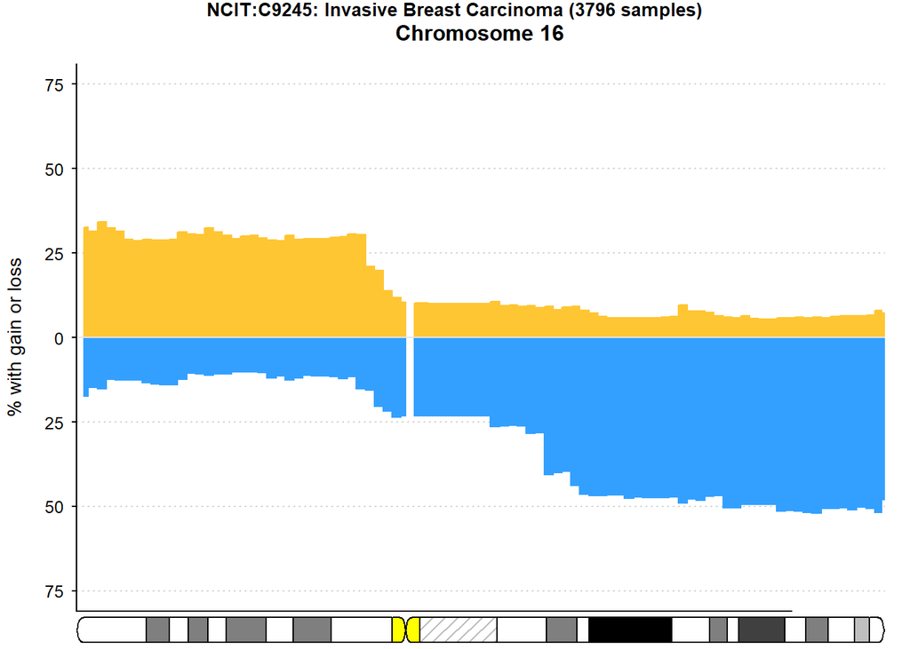

```r
pgxFreqplot(freq, chrom=16)
```

Chromosome 16 is a clear case for deletions of CN’s.

# Data Analysis

Chromosome gains and deletions for a 25% threshold are shown here.

According to the plot, there are several gains of CN’s on the  
chromosom:  
1q, 8q, 16p, 17q, 20q

And several deletions on chromosom:  
1p, 4pq, 6q, 8p, 9pq, 11q, 13q, 15q, 16q, 17p, 18q, 22q, Xpq

In the Study: [Genomic alterations during the in situ to invasive ductal breast carcinoma transition shaped by the immune system][https://www.ncbi.nlm.nih.gov/pmc/articles/PMC8026652/]  
we compare ceratin deletions and gains of the CN’s.

From the Study you get:  
Amplification: 1q, 8q, 17q, 20q  
Deletions: 8p, 11q, 16q, 17p

Comparing from the study with the library

The overlaps for duplication are:  
1q, 8q, 17q, 20q

As well for the deletionsare:  
8p, 11q, 16q, 17p

# conclusion

It can be said that the chromosomes 1q, 8q, 17q, 20q -gains and 8p, 11q, 16q, 17p - deletions correlate with breast cancer with a very high probability, as they are found in the Protogenix library on the one hand, as well as being mentioned in an independent study.